# MovieLens Project Questions

### `Project - MovieLens Data Analysis`

The GroupLens Research Project is a research group in the Department of Computer Science and Engineering at the University of Minnesota. The data is widely used for collaborative filtering and other filtering solutions. However, we will be using this data to act as a means to demonstrate our skill in using Python to “play” with data.

### `Objective:`

- To implement the techniques learnt as a part of the course.

### `Learning Outcomes:`

- Exploratory Data Analysis
- Visualization using Python
- Pandas – groupby, merging

### `Domain`

- Internet and Entertainment

**Note that the project will need you to apply the concepts of groupby and merging extensively.**

### `Datasets Information:`

*rating.csv:* It contains information on ratings given by the users to a particular movie.

- user id: id assigned to every user
- movie id: id assigned to every movie
- rating: rating given by the user
- timestamp: Time recorded when the user gave a rating

*movie.csv:* File contains information related to the movies and their genre.

- movie id: id assigned to every movie
- movie title: Title of the movie
- release date: Date of release of the movie
- Action: Genre containing binary values (1 - for action 0 - not action)
- Adventure: Genre containing binary values (1 - for adventure 0 - not adventure)
- Animation: Genre containing binary values (1 - for animation 0 - not animation)
- Children’s: Genre containing binary values (1 - for children's 0 - not children's)
- Comedy: Genre containing binary values (1 - for comedy 0 - not comedy)
- Crime: Genre containing binary values (1 - for crime 0 - not crime)
- Documentary: Genre containing binary values (1 - for documentary 0 - not documentary)
- Drama: Genre containing binary values (1 - for drama 0 - not drama)
- Fantasy: Genre containing binary values (1 - for fantasy 0 - not fantasy)
- Film-Noir: Genre containing binary values (1 - for film-noir 0 - not film-noir)
- Horror: Genre containing binary values (1 - for horror 0 - not horror)
- Musical: Genre containing binary values (1 - for musical 0 - not musical)
- Mystery: Genre containing binary values (1 - for mystery 0 - not mystery)
- Romance: Genre containing binary values (1 - for romance 0 - not romance)
- Sci-Fi: Genre containing binary values (1 - for sci-fi 0 - not sci-fi)
- Thriller: Genre containing binary values (1 - for thriller 0 - not thriller)
- War: Genre containing binary values (1 - for war 0 - not war)
- Western: Genre containing binary values (1 - for western - not western)

*user.csv:* It contains information of the users who have rated the movies.

- user id: id assigned to every user
- age: Age of the user
- gender: Gender of the user
- occupation: Occupation of the user
- zip code: Zip code of the use

**`Please provide you insights wherever necessary.`**

### 1. Import the necessary packages - 2.5 marks

```python
# Importing All libraries needed
import pandas as pd
import numpy as np
from matplotlib import pyplot as plt
import seaborn as sns
%matplotlib inline
import warnings
warnings.filterwarnings('ignore')
```

### 2. Read the 3 datasets into dataframes - 2.5 marks

```python
# Reading and loading dataframes with data from files provided
df_ratings = pd.read_csv("data.csv") #Reading data.csv for ratings data into a dataframe
df_movie = pd.read_csv("item.csv") #Reading item.csv for movie data into a dataframe
df_users = pd.read_csv("user.csv") #Reading user.csv for users data into a dataframe
```

### 3. Apply info, shape, describe, and find the number of missing values in the data - 5 marks

- Note that you will need to do it for all the three datasets seperately

```python
#Applying info on the 3 dataframes to see what is the nature of the data/datatypes
print("*******************************")
df_ratings.info();
print("*******************************")
df_movie.info();
print("*******************************")
df_users.info();
```

```
<class 'pandas.core.frame.DataFrame'>
RangeIndex: 100000 entries, 0 to 99999
Data columns (total 4 columns):
 #   Column     Non-Null Count   Dtype
---  ------     --------------   -----
 0   user id    100000 non-null  int64
 1   movie id   100000 non-null  int64
 2   rating     100000 non-null  int64
 3   timestamp  100000 non-null  int64
dtypes: int64(4)
memory usage: 3.1 MB
<class 'pandas.core.frame.DataFrame'>
RangeIndex: 1681 entries, 0 to 1680
Data columns (total 22 columns):
 #   Column        Non-Null Count  Dtype
---  ------        --------------  -----
 0   movie id      1681 non-null   int64
 1   movie title   1681 non-null   object
 2   release date  1681 non-null   object
 3   unknown       1681 non-null   int64
 4   Action        1681 non-null   int64
 5   Adventure     1681 non-null   int64
 6   Animation     1681 non-null   int64
 7   Childrens     1681 non-null   int64
 8   Comedy        1681 non-null   int64
 9   Crime         1681 non-null   int64
 10  Documentary   1681 non-null   int64
 11  Drama         1681 non-null   int64
 12  Fantasy       1681 non-null   int64
 13  Film-Noir     1681 non-null   int64
 14  Horror        1681 non-null   int64
 15  Musical       1681 non-null   int64
 16  Mystery       1681 non-null   int64
 17  Romance       1681 non-null   int64
 18  Sci-Fi        1681 non-null   int64
 19  Thriller      1681 non-null   int64
 20  War           1681 non-null   int64
 21  Western       1681 non-null   int64
dtypes: int64(20), object(2)
memory usage: 289.0+ KB
<class 'pandas.core.frame.DataFrame'>
RangeIndex: 943 entries, 0 to 942
Data columns (total 5 columns):
 #   Column      Non-Null Count  Dtype
---  ------      --------------  -----
 0   user id     943 non-null    int64
 1   age         943 non-null    int64
 2   gender      943 non-null    object
 3   occupation  943 non-null    object
 4   zip code    943 non-null    object
dtypes: int64(2), object(3)
memory usage: 37.0+ KB
```

```python
#Applying shape on the 3 dataframes to see the number of rows and columns that need to be dealt with
print("*******************************")
print(f'Shape of Ratings DataFrame is {df_ratings.shape}')
print("*******************************")
print(f'Shape of Movie DataFrame is {df_movie.shape}')
print("*******************************")
print(f'Shape of Users DataFrame is {df_users.shape}')
print("*******************************")
```

```
Shape of Ratings DataFrame is (100000, 4)
Shape of Movie DataFrame is (1681, 22)
Shape of Users DataFrame is (943, 5)
```

```python
# Checking datatypes in the 3 dataframes
print("*******************************")
print("Ratings Data from data.csv")
print(df_ratings.describe())
print("*******************************")
print("Movie Data from item.csv")
print(df_movie.describe())
print("*******************************")
print("Users Data from user.csv")
print(df_users.describe())
print("*******************************")
```

```
Ratings Data from data.csv
            user id       movie id         rating     timestamp
count  100000.00000  100000.000000  100000.000000  1.000000e+05
mean      462.48475     425.530130       3.529860  8.835289e+08
std       266.61442     330.798356       1.125674  5.343856e+06
min         1.00000       1.000000       1.000000  8.747247e+08
25%       254.00000     175.000000       3.000000  8.794487e+08
50%       447.00000     322.000000       4.000000  8.828269e+08
75%       682.00000     631.000000       4.000000  8.882600e+08
max       943.00000    1682.000000       5.000000  8.932866e+08
Movie Data from item.csv
          movie id      unknown       Action    Adventure    Animation  \
count  1681.000000  1681.000000  1681.000000  1681.000000  1681.000000
mean    841.841761     0.000595     0.149316     0.080309     0.024985
std     485.638077     0.024390     0.356506     0.271852     0.156126
min       1.000000     0.000000     0.000000     0.000000     0.000000
25%     422.000000     0.000000     0.000000     0.000000     0.000000
50%     842.000000     0.000000     0.000000     0.000000     0.000000
75%    1262.000000     0.000000     0.000000     0.000000     0.000000
max    1682.000000     1.000000     1.000000     1.000000     1.000000

         Childrens       Comedy        Crime  Documentary        Drama  \
count  1681.000000  1681.000000  1681.000000  1681.000000  1681.000000
mean      0.072576     0.300416     0.064842     0.029744     0.431291
std       0.259516     0.458576     0.246321     0.169931     0.495404
min       0.000000     0.000000     0.000000     0.000000     0.000000
25%       0.000000     0.000000     0.000000     0.000000     0.000000
50%       0.000000     0.000000     0.000000     0.000000     0.000000
75%       0.000000     1.000000     0.000000     0.000000     1.000000
max       1.000000     1.000000     1.000000     1.000000     1.000000

           Fantasy    Film-Noir       Horror      Musical      Mystery  \
count  1681.000000  1681.000000  1681.000000  1681.000000  1681.000000
mean      0.013087     0.014277     0.054729     0.033314     0.036288
std       0.113683     0.118667     0.227519     0.179507     0.187061
min       0.000000     0.000000     0.000000     0.000000     0.000000
25%       0.000000     0.000000     0.000000     0.000000     0.000000
50%       0.000000     0.000000     0.000000     0.000000     0.000000
75%       0.000000     0.000000     0.000000     0.000000     0.000000
max       1.000000     1.000000     1.000000     1.000000     1.000000

           Romance       Sci-Fi     Thriller          War      Western
count  1681.000000  1681.000000  1681.000000  1681.000000  1681.000000
mean      0.146936     0.060083     0.149316     0.042237     0.016062
std       0.354148     0.237712     0.356506     0.201189     0.125751
min       0.000000     0.000000     0.000000     0.000000     0.000000
25%       0.000000     0.000000     0.000000     0.000000     0.000000
50%       0.000000     0.000000     0.000000     0.000000     0.000000
75%       0.000000     0.000000     0.000000     0.000000     0.000000
max       1.000000     1.000000     1.000000     1.000000     1.000000
Users Data from user.csv
          user id         age
count  943.000000  943.000000
mean   472.000000   34.051962
std    272.364951   12.192740
min      1.000000    7.000000
25%    236.500000   25.000000
50%    472.000000   31.000000
75%    707.500000   43.000000
max    943.000000   73.000000
```

### 4. Find the number of movies per genre using the item data - 2.5 marks

```python
# df_genre_count = df_movie.sum().reset_index().iloc[3:]
# print(df_genre_count)
```

```python
df_genre_count = df_movie.sum().reset_index().iloc[3:] #Suming up all Gener columns and eliminating other columns
df_genre_count.columns=["Gener", "Movie Count"] #Renaming Columns names
df_genre_count.set_index("Gener", inplace=True) #Setting index as "Gener" to make the output readibility better
print(df_genre_count) #Dispaling the result DataFrame
```

```
            Movie Count
Gener
unknown               1
Action              251
Adventure           135
Animation            42
Childrens           122
Comedy              505
Crime               109
Documentary          50
Drama               725
Fantasy              22
Film-Noir            24
Horror               92
Musical              56
Mystery              61
Romance             247
Sci-Fi              101
Thriller            251
War                  71
Western              27
```

### 5. Drop the movie where the genre is unknown - 2.5 marks

```python
df_movie.drop(df_movie[df_movie["unknown"]==1].index, inplace=True) #Dropping row with Gener as unknown
print(df_movie[df_movie["unknown"]==1]) #Print all rows with Gener unknown is 1 to check if the drop statement above worked
```

[output not shown]

### 6. Find the movies that have more than one genre - 5 marks

hint: use sum on the axis = 1

Display movie name, number of genres for the movie in dataframe

and also print(total number of movies which have more than one genres)

```python
df_movie["gener_sum"] = df_movie[df_movie.columns[3:22]].sum(axis=1) #Adding a column to the df_movie dataframe which holds the sum of all geners
print("Displaying movie name, number of genres for the movie in dataframe")
print(df_movie[["movie title","gener_sum"]]) #Displaying movie name, number of genres for the movie in dataframe
print("*******************************")
print("Total number of movies which have more than one genres")
df_movie[df_movie["gener_sum"]>1]["movie title"].count() #Q2
```

```
Displaying movie name, number of genres for the movie in dataframe
                              movie title  gener_sum
0                              Toy Story           3
1                              GoldenEye           3
2                             Four Rooms           1
3                             Get Shorty           3
4                                Copycat           3
...                                   ...        ...
1676                          Mat' i syn           1
1677                           B. Monkey           2
1678                       Sliding Doors           2
1679                        You So Crazy           1
1680  Scream of Stone (Schrei aus Stein)           1

[1680 rows x 2 columns]
Total number of movies which have more than one genres
```

```
849
```

### 7. Univariate plots of columns: 'rating', 'Age', 'release year', 'Gender' and 'Occupation' - 10 marks

*HINT: Use distplot for age. Use lineplot or countplot for release year.*

*HINT: Plot percentages in y-axis and categories in x-axis for ratings, gender and occupation*

*HINT: Please refer to the below snippet to understand how to get to release year from release date. You can use str.split() as depicted below or you could convert it to pandas datetime format and extract year (.dt.year)*

```python
df_movie['year'] = df_movie["release date"].str[-4:] #Adding a column to the df_movie and populating it with the year of the release
```

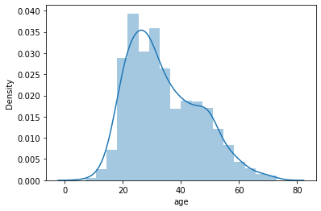

```python
sns.distplot(df_users['age']); #Plotting age with the density using histogram
```

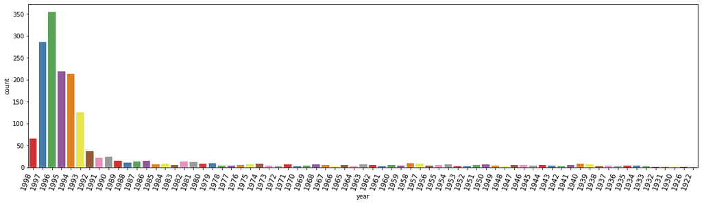

```python
plt.figure(figsize=(20,5))
sns.countplot(df_movie['year'].sort_values(ascending=False), palette='Set1'); #Plotting count vs year using countplot
plt.xticks(rotation=70, horizontalalignment='right', fontsize='large');
```

```python
# Taking Ratings and counts into a seperated dataframe
df_rperct = df_ratings.groupby("rating").count()["user id"].reset_index()
df_rperct.columns = ["rating","cnt"]
```

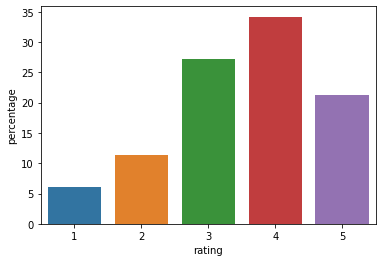

```python
# Plot percentages in y-axis and categories in x-axis for ratings
df_rperct["percentage"] = df_rperct["cnt"] / df_rperct["cnt"].sum()*100
sns.barplot(data = df_rperct, x="rating", y="percentage");
```

```python
# Taking Gender and counts into a seperated dataframe
df_gperct = df_users.groupby("gender").count()["user id"].reset_index()
df_gperct.columns = ["gender","cnt"]
```

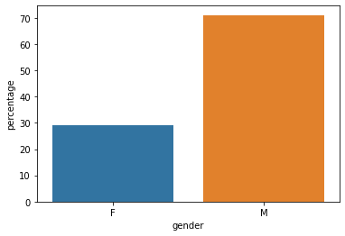

```python
# Plot percentages in y-axis and categories in x-axis for gender
df_gperct["percentage"] = df_gperct["cnt"] / df_gperct["cnt"].sum()*100
sns.barplot(data = df_gperct, x="gender", y="percentage");
```

```python
# Taking Occupation and counts into a seperated dataframe
df_operct = df_users.groupby("occupation").count()["user id"].reset_index()
df_operct.columns = ["occupation","cnt"]
```

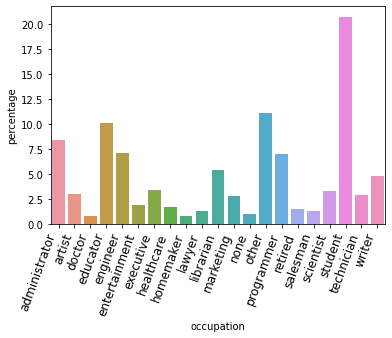

```python
df_operct["percentage"] = df_operct["cnt"] / df_operct["cnt"].sum()*100
sns.barplot(data = df_operct, x="occupation", y="percentage"); # Plot percentages in y-axis and categories in x-axis for occupation
plt.xticks(rotation=70, horizontalalignment='right', fontsize='large');
```

### 8. Visualize how popularity of genres has changed over the years - 10 marks

Note that you need to use the **percent of number of releases in a year** as a parameter of popularity of a genre

Hint 1: You need to reach to a data frame where the release year is the index and the genre is the column names (one cell shows the number of release in a year in one genre) or vice versa. (Drop unnecessary column if there are any)

Hint 2: Find the total number of movies release in a year(use `sum(axis=1)` store that value in a new column as 'total'). Now divide the value of each genre in that year by total to get percentage number of release in a particular year. `(df.div(df['total'], axis= 0) * 100)`

Once that is achieved, you can either use univariate plots or can use the heatmap to visualise all the changes over the years in one go.

Hint 3: Use groupby on the relevant column and use sum() on the same to find out the number of releases in a year/genre.

```python
# Grouping by year and taking the sum of all geners to evaluate how many movies were under a particular gener for each year
df_popular = df_movie.groupby("year").sum().iloc[:,2:20]
```

```python
# Creating a dataframe df_pct with joinging df_popular and df view to evalutate number of movies released in that year "movie count"
df_pct = df_popular.join(df_movie.groupby("year").count()["movie title"], on="year").rename({"movie title":"movie count"}, axis=1)
df_pct
```

| year | Action | Adventure | Animation | Childrens | Comedy | Crime | Documentary | Drama | Fantasy | Film-Noir | Horror | Musical | Mystery | Romance | Sci-Fi | Thriller | War | Western | movie count |
| --- | --- | --- | --- | --- | --- | --- | --- | --- | --- | --- | --- | --- | --- | --- | --- | --- | --- | --- | --- |
| 1922 | 0 | 0 | 0 | 0 | 0 | 0 | 0 | 0 | 0 | 0 | 1 | 0 | 0 | 0 | 0 | 0 | 0 | 0 | 1 |
| 1926 | 0 | 0 | 0 | 0 | 0 | 0 | 0 | 1 | 0 | 0 | 0 | 0 | 0 | 0 | 0 | 0 | 0 | 0 | 1 |
| 1930 | 0 | 0 | 0 | 0 | 0 | 0 | 0 | 1 | 0 | 0 | 0 | 0 | 0 | 0 | 0 | 0 | 0 | 0 | 1 |
| 1931 | 0 | 0 | 0 | 0 | 0 | 1 | 0 | 0 | 0 | 1 | 0 | 0 | 0 | 0 | 0 | 1 | 0 | 0 | 1 |
| 1932 | 0 | 0 | 0 | 0 | 0 | 0 | 0 | 0 | 0 | 0 | 0 | 0 | 0 | 1 | 0 | 0 | 1 | 0 | 1 |
| ... | ... | ... | ... | ... | ... | ... | ... | ... | ... | ... | ... | ... | ... | ... | ... | ... | ... | ... | ... |
| 1994 | 30 | 13 | 4 | 15 | 82 | 8 | 9 | 97 | 3 | 0 | 8 | 2 | 2 | 35 | 7 | 25 | 7 | 6 | 214 |
| 1995 | 40 | 22 | 6 | 21 | 63 | 11 | 5 | 89 | 3 | 1 | 14 | 3 | 5 | 37 | 15 | 39 | 5 | 2 | 219 |
| 1996 | 44 | 24 | 9 | 21 | 108 | 21 | 18 | 170 | 6 | 1 | 11 | 9 | 6 | 38 | 15 | 47 | 9 | 2 | 355 |
| 1997 | 46 | 20 | 3 | 22 | 87 | 30 | 6 | 113 | 4 | 2 | 8 | 5 | 18 | 51 | 13 | 54 | 14 | 0 | 286 |
| 1998 | 12 | 3 | 0 | 1 | 13 | 7 | 3 | 33 | 1 | 2 | 4 | 1 | 3 | 11 | 5 | 18 | 0 | 0 | 65 |

71 rows × 19 columns

```python
# Creating Dataframe with percentage per gener w.r.t. number of movies released in that year
df_plot = df_pct.div(df_pct["movie count"],axis=0)*100
df_plot.drop("movie count", axis=1, inplace=True) #Dropping the movie count column to get only the required columns
df_plot
```

| year | Action | Adventure | Animation | Childrens | Comedy | Crime | Documentary | Drama | Fantasy | Film-Noir | Horror | Musical | Mystery | Romance | Sci-Fi | Thriller | War | Western |
| --- | --- | --- | --- | --- | --- | --- | --- | --- | --- | --- | --- | --- | --- | --- | --- | --- | --- | --- |
| 1922 | 0.000000 | 0.000000 | 0.000000 | 0.000000 | 0.000000 | 0.000000 | 0.000000 | 0.000000 | 0.000000 | 0.000000 | 100.000000 | 0.000000 | 0.000000 | 0.000000 | 0.000000 | 0.000000 | 0.000000 | 0.000000 |
| 1926 | 0.000000 | 0.000000 | 0.000000 | 0.000000 | 0.000000 | 0.000000 | 0.000000 | 100.000000 | 0.000000 | 0.000000 | 0.000000 | 0.000000 | 0.000000 | 0.000000 | 0.000000 | 0.000000 | 0.000000 | 0.000000 |
| 1930 | 0.000000 | 0.000000 | 0.000000 | 0.000000 | 0.000000 | 0.000000 | 0.000000 | 100.000000 | 0.000000 | 0.000000 | 0.000000 | 0.000000 | 0.000000 | 0.000000 | 0.000000 | 0.000000 | 0.000000 | 0.000000 |
| 1931 | 0.000000 | 0.000000 | 0.000000 | 0.000000 | 0.000000 | 100.000000 | 0.000000 | 0.000000 | 0.000000 | 100.000000 | 0.000000 | 0.000000 | 0.000000 | 0.000000 | 0.000000 | 100.000000 | 0.000000 | 0.000000 |
| 1932 | 0.000000 | 0.000000 | 0.000000 | 0.000000 | 0.000000 | 0.000000 | 0.000000 | 0.000000 | 0.000000 | 0.000000 | 0.000000 | 0.000000 | 0.000000 | 100.000000 | 0.000000 | 0.000000 | 100.000000 | 0.000000 |
| ... | ... | ... | ... | ... | ... | ... | ... | ... | ... | ... | ... | ... | ... | ... | ... | ... | ... | ... |
| 1994 | 14.018692 | 6.074766 | 1.869159 | 7.009346 | 38.317757 | 3.738318 | 4.205607 | 45.327103 | 1.401869 | 0.000000 | 3.738318 | 0.934579 | 0.934579 | 16.355140 | 3.271028 | 11.682243 | 3.271028 | 2.803738 |
| 1995 | 18.264840 | 10.045662 | 2.739726 | 9.589041 | 28.767123 | 5.022831 | 2.283105 | 40.639269 | 1.369863 | 0.456621 | 6.392694 | 1.369863 | 2.283105 | 16.894977 | 6.849315 | 17.808219 | 2.283105 | 0.913242 |
| 1996 | 12.394366 | 6.760563 | 2.535211 | 5.915493 | 30.422535 | 5.915493 | 5.070423 | 47.887324 | 1.690141 | 0.281690 | 3.098592 | 2.535211 | 1.690141 | 10.704225 | 4.225352 | 13.239437 | 2.535211 | 0.563380 |
| 1997 | 16.083916 | 6.993007 | 1.048951 | 7.692308 | 30.419580 | 10.489510 | 2.097902 | 39.510490 | 1.398601 | 0.699301 | 2.797203 | 1.748252 | 6.293706 | 17.832168 | 4.545455 | 18.881119 | 4.895105 | 0.000000 |
| 1998 | 18.461538 | 4.615385 | 0.000000 | 1.538462 | 20.000000 | 10.769231 | 4.615385 | 50.769231 | 1.538462 | 3.076923 | 6.153846 | 1.538462 | 4.615385 | 16.923077 | 7.692308 | 27.692308 | 0.000000 | 0.000000 |

71 rows × 18 columns

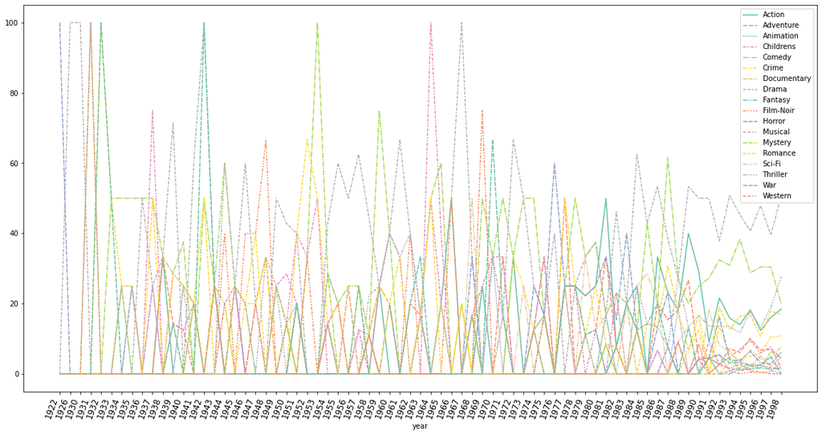

```python
# Plotting df_plot for percentage vs year to see the output
plt.figure(figsize=(20,10))
sns.lineplot(data=df_plot, palette='Set2')
plt.xticks(rotation=70, horizontalalignment='right', fontsize='large');
```

### 9. Find the top 25 movies according to average ratings such that each movie has number of ratings more than 100 - 10 marks

Hints :

1. Find the count of ratings and average ratings for every movie.
2. Slice the movies which have ratings more than 100.
3. Sort values according to average rating such that movie which highest rating is on top.
4. Select top 25 movies.
5. You will have to use the .merge() function to get the movie titles.

Note: This question will need you to research about groupby and apply your findings. You can find more on groupby on https://realpython.com/pandas-groupby/.

```python
# Creating a DataFrame df_top25 and populating it with the count of ratings
df_top25 = df_ratings.groupby("movie id")["rating"].count().reset_index()
df_top25.columns = ["movie id","ratings_cnt"]
df_top25
```

|  | movie id | ratings_cnt |
| --- | --- | --- |
| 0 | 1 | 452 |
| 1 | 2 | 131 |
| 2 | 3 | 90 |
| 3 | 4 | 209 |
| 4 | 5 | 86 |
| ... | ... | ... |
| 1677 | 1678 | 1 |
| 1678 | 1679 | 1 |
| 1679 | 1680 | 1 |
| 1680 | 1681 | 1 |
| 1681 | 1682 | 1 |

1682 rows × 2 columns

```python
# Finding the avg rating for each movie id
df_top25["avg_rating"] = df_ratings.groupby("movie id")["rating"].mean().reset_index()["rating"]
df_top25
```

|  | movie id | ratings_cnt | avg_rating |
| --- | --- | --- | --- |
| 0 | 1 | 452 | 3.878319 |
| 1 | 2 | 131 | 3.206107 |
| 2 | 3 | 90 | 3.033333 |
| 3 | 4 | 209 | 3.550239 |
| 4 | 5 | 86 | 3.302326 |
| ... | ... | ... | ... |
| 1677 | 1678 | 1 | 1.000000 |
| 1678 | 1679 | 1 | 3.000000 |
| 1679 | 1680 | 1 | 2.000000 |
| 1680 | 1681 | 1 | 3.000000 |
| 1681 | 1682 | 1 | 3.000000 |

1682 rows × 3 columns

```python
# Getting movies with more than 100 ratings
df_top25[df_top25["ratings_cnt"]>100]
```

|  | movie id | ratings_cnt | avg_rating |
| --- | --- | --- | --- |
| 0 | 1 | 452 | 3.878319 |
| 1 | 2 | 131 | 3.206107 |
| 3 | 4 | 209 | 3.550239 |
| 6 | 7 | 392 | 3.798469 |
| 7 | 8 | 219 | 3.995434 |
| ... | ... | ... | ... |
| 925 | 926 | 101 | 2.702970 |
| 927 | 928 | 104 | 3.115385 |
| 1015 | 1016 | 137 | 3.459854 |
| 1027 | 1028 | 148 | 3.040541 |
| 1046 | 1047 | 134 | 2.835821 |

334 rows × 3 columns

```python
# Sorting the dataset with more than 100 ratings using avg rating as key and taking the top 25
df_top25[df_top25["ratings_cnt"]>100].sort_values("avg_rating", ascending=False).head(25)
```

|  | movie id | ratings_cnt | avg_rating |
| --- | --- | --- | --- |
| 407 | 408 | 112 | 4.491071 |
| 317 | 318 | 298 | 4.466443 |
| 168 | 169 | 118 | 4.466102 |
| 482 | 483 | 243 | 4.456790 |
| 63 | 64 | 283 | 4.445230 |
| 602 | 603 | 209 | 4.387560 |
| 11 | 12 | 267 | 4.385768 |
| 49 | 50 | 583 | 4.358491 |
| 177 | 178 | 125 | 4.344000 |
| 133 | 134 | 198 | 4.292929 |
| 426 | 427 | 219 | 4.292237 |
| 356 | 357 | 264 | 4.291667 |
| 97 | 98 | 390 | 4.289744 |
| 479 | 480 | 179 | 4.284916 |
| 126 | 127 | 413 | 4.283293 |
| 284 | 285 | 162 | 4.265432 |
| 271 | 272 | 198 | 4.262626 |
| 656 | 657 | 131 | 4.259542 |
| 473 | 474 | 194 | 4.252577 |
| 173 | 174 | 420 | 4.252381 |
| 478 | 479 | 179 | 4.251397 |
| 312 | 313 | 350 | 4.245714 |
| 510 | 511 | 173 | 4.231214 |
| 483 | 484 | 138 | 4.210145 |
| 171 | 172 | 367 | 4.204360 |

```python
# Using merge function to get the top 25 movie names
df_top25[df_top25["ratings_cnt"]>100].sort_values("avg_rating", ascending=False).head(25).merge(df_movie, on="movie id")[["movie title", "avg_rating", "ratings_cnt"]]
```

|  | movie title | avg_rating | ratings_cnt |
| --- | --- | --- | --- |
| 0 | Close Shave, A | 4.491071 | 112 |
| 1 | Schindler's List | 4.466443 | 298 |
| 2 | Wrong Trousers, The | 4.466102 | 118 |
| 3 | Casablanca | 4.456790 | 243 |
| 4 | Shawshank Redemption, The | 4.445230 | 283 |
| 5 | Rear Window | 4.387560 | 209 |
| 6 | Usual Suspects, The | 4.385768 | 267 |
| 7 | Star Wars | 4.358491 | 583 |
| 8 | 12 Angry Men | 4.344000 | 125 |
| 9 | Citizen Kane | 4.292929 | 198 |
| 10 | To Kill a Mockingbird | 4.292237 | 219 |
| 11 | One Flew Over the Cuckoo's Nest | 4.291667 | 264 |
| 12 | Silence of the Lambs, The | 4.289744 | 390 |
| 13 | North by Northwest | 4.284916 | 179 |
| 14 | Godfather, The | 4.283293 | 413 |
| 15 | Secrets & Lies | 4.265432 | 162 |
| 16 | Good Will Hunting | 4.262626 | 198 |
| 17 | Manchurian Candidate, The | 4.259542 | 131 |
| 18 | Dr. Strangelove or: How I Learned to Stop Worr... | 4.252577 | 194 |
| 19 | Raiders of the Lost Ark | 4.252381 | 420 |
| 20 | Vertigo | 4.251397 | 179 |
| 21 | Titanic | 4.245714 | 350 |
| 22 | Lawrence of Arabia | 4.231214 | 173 |
| 23 | Maltese Falcon, The | 4.210145 | 138 |
| 24 | Empire Strikes Back, The | 4.204360 | 367 |

### 10. See gender distribution across different genres check for the validity of the below statements - 10 marks

- Men watch more drama than women
- Women watch more Sci-Fi than men
- Men watch more Romance than women

**compare the percentages**

1. Merge all the datasets
2. There is no need to conduct statistical tests around this. Just **compare the percentages** and comment on the validity of the above statements.
3. you might want ot use the .sum(), .div() function here.
4. Use number of ratings to validate the numbers. For example, if out of 4000 ratings received by women, 3000 are for drama, we will assume that 75% of the women watch drama.

```python
# Merging all datasets
df_merged = df_movie.merge(df_ratings, on="movie id").merge(df_users, on="user id")
df_merged
```

|  | movie id | movie title | release date | unknown | Action | Adventure | Animation | Childrens | Comedy | Crime | ... | Western | gener_sum | year | user id | rating | timestamp | age | gender | occupation | zip code |
| --- | --- | --- | --- | --- | --- | --- | --- | --- | --- | --- | --- | --- | --- | --- | --- | --- | --- | --- | --- | --- | --- |
| 0 | 1 | Toy Story | 01-Jan-1995 | 0 | 0 | 0 | 1 | 1 | 1 | 0 | ... | 0 | 3 | 1995 | 308 | 4 | 887736532 | 60 | M | retired | 95076 |
| 1 | 4 | Get Shorty | 01-Jan-1995 | 0 | 1 | 0 | 0 | 0 | 1 | 0 | ... | 0 | 3 | 1995 | 308 | 5 | 887737890 | 60 | M | retired | 95076 |
| 2 | 5 | Copycat | 01-Jan-1995 | 0 | 0 | 0 | 0 | 0 | 0 | 1 | ... | 0 | 3 | 1995 | 308 | 4 | 887739608 | 60 | M | retired | 95076 |
| 3 | 7 | Twelve Monkeys | 01-Jan-1995 | 0 | 0 | 0 | 0 | 0 | 0 | 0 | ... | 0 | 2 | 1995 | 308 | 4 | 887738847 | 60 | M | retired | 95076 |
| 4 | 8 | Babe | 01-Jan-1995 | 0 | 0 | 0 | 0 | 1 | 1 | 0 | ... | 0 | 3 | 1995 | 308 | 5 | 887736696 | 60 | M | retired | 95076 |
| ... | ... | ... | ... | ... | ... | ... | ... | ... | ... | ... | ... | ... | ... | ... | ... | ... | ... | ... | ... | ... | ... |
| 99985 | 748 | Saint, The | 14-Mar-1997 | 0 | 1 | 0 | 0 | 0 | 0 | 0 | ... | 0 | 3 | 1997 | 729 | 4 | 893286638 | 19 | M | student | 56567 |
| 99986 | 751 | Tomorrow Never Dies | 01-Jan-1997 | 0 | 1 | 0 | 0 | 0 | 0 | 0 | ... | 0 | 3 | 1997 | 729 | 3 | 893286338 | 19 | M | student | 56567 |
| 99987 | 879 | Peacemaker, The | 01-Jan-1997 | 0 | 1 | 0 | 0 | 0 | 0 | 0 | ... | 0 | 3 | 1997 | 729 | 3 | 893286299 | 19 | M | student | 56567 |
| 99988 | 894 | Home Alone 3 | 01-Jan-1997 | 0 | 0 | 0 | 0 | 1 | 1 | 0 | ... | 0 | 2 | 1997 | 729 | 1 | 893286511 | 19 | M | student | 56567 |
| 99989 | 901 | Mr. Magoo | 25-Dec-1997 | 0 | 0 | 0 | 0 | 0 | 1 | 0 | ... | 0 | 1 | 1997 | 729 | 1 | 893286491 | 19 | M | student | 56567 |

99990 rows × 31 columns

```python
# Getting total number of women who rated movies
num_women = df_ratings.merge(df_users, how="inner")[df_ratings.merge(df_users, how="inner")["gender"]=="F"].count()["user id"]
# Getting total number of men who rated movies
num_men = df_ratings.merge(df_users, how="inner")[df_ratings.merge(df_users, how="inner")["gender"]=="M"].count()["user id"]
```

```python
df_drama = df_merged.groupby(["gender"])[["gender","Drama"]].sum("Drama") #GroupBy gender and summing for Gener Drama
df_drama["prct"] = np.NAN
df_drama.loc["F",'prct'] = (df_drama["Drama"]["F"]/num_women)*100 #Adding column for percentage (No of women who voted for Drama/Total number of women who rated)
df_drama.loc["M",'prct'] = (df_drama["Drama"]["M"]/num_men)*100 #Adding column for percentage (No of men who voted for Drama/Total number of men who rated)
df_drama
```

| gender | Drama | prct |
| --- | --- | --- |
| F | 11008 | 42.766123 |
| M | 28887 | 38.899811 |

```python
df_scifi = df_merged.groupby(["gender"])[["gender","Sci-Fi"]].sum("Sci-Fi") #GroupBy gender and summing for Gener Sci-Fi
df_scifi["prct"] = np.NAN
df_scifi.loc["F",'prct'] = (df_scifi["Sci-Fi"]["F"]/num_women)*100 #Adding column for percentage (No of women who voted for Sc-Fi/Total number of women who rated)
df_scifi.loc["M",'prct'] = (df_scifi["Sci-Fi"]["M"]/num_men)*100 #Adding column for percentage (No of men who voted for Sc-Fi/Total number of men who rated)
df_scifi
```

| gender | Sci-Fi | prct |
| --- | --- | --- |
| F | 2629 | 10.213675 |
| M | 10101 | 13.602208 |

```python
df_romance = df_merged.groupby(["gender"])[["gender","Romance"]].sum("Romance") #GroupBy gender and summing for Gener Romance
df_romance["prct"] = np.NAN
df_romance.loc["F",'prct'] = (df_romance["Romance"]["F"]/num_women)*100 #Adding column for percentage (No of women who voted for Romance movies/Total number of women who rated)
df_romance.loc["M",'prct'] = (df_romance["Romance"]["M"]/num_men)*100 #Adding column for percentage (No of men who voted for Romance movies/Total number of men who rated)
df_romance
```

[output not shown]